# Final Assignment

delkh

AT 2023

[Repository](https://github.com/delkh/Delkh_final_assignment_472.git)

Research question: “Rolling Stone Magazine ranked their 100 greatest musical artists of all time. At the end of 2023, how has their music endured? Are there any features or characteristics that seem to explain enduring engagement?”

primary sources:

[Rolling Stone’s 100 Greatest Artists, 2010](https://www.rollingstone.com/music/music-lists/100-greatest-artists-147446/)

[Spotify Web API](https://developer.spotify.com/documentation/web-api)

Introduction:

To understand the endurance of these musical icons, we can perceive lasting engagement with their music as a measure of its endurance. Given the absence of universally accessible historical engagement data, I’ve employed Spotify’s “Popularity” score as a metric reflecting people’s current engagement with an artists’ music. However, evaluating enduring engagement necessitates a practical reference point. Taylor Swift was ranked as the most popular musical artist in 2023, thus we can use her ‘popularity’ score as a relevant benchmark. Aligning with our assumption that “endurance” denotes lasting engagement, comparing these legendary artists’ “Popularity” scores to Swift’s offers valuable insights into their relative resilience and lasting impact. If these iconic artists approach or surpass a predetermined threshold—such as 50% of Taylor Swift’s standing—it shows significant endurance.

I have examined genre as a main characteristic that could influence endurance. While examining genres may provide some insights into the relevance these artists over time, it remains one facet of a multifaceted analysis. Regrettably, the analysis is constrained.

Data:

Initially, a web scraper was created to extract artist names and their rankings from the Rolling Stone’s article, aggregating this information into a table named “artists_table.”

Access to the Spotify Web API was first established. A function was then developed to fetch artist data– including name, genre, popularity score, and followers- from Spotify’s API. This function was systematically applied to each artist in the list, enabling the compilation of artist information for all 100 artists featured in Rolling Stone’s list as well as Taylor Swift.

The decision to prioritize popularity scores over follower counts was driven by a distinctive difference in distributions. While popularity scores exhibited a more balanced and representative spread, follower counts displayed a considerably skewed distribution characterized by numerous outliers. Popularity scores showed a tighter distribution with only one outlier at a score of 0 (see Figure 1). The mean and median values for popularity scores were 65.24 and 67, respectively, with quartile values at 56 and 75.25. In contrast, follower counts presented a broader range, causing a distribution heavily impacted by outliers (See figure 2). The mean_followers value was 6,634,782, with a median_followers of 2,588,247 and quartiles at 1,071,410 and 7,187,520.

Analysis: To assess the spread of artists’ enduring engagement, I systematically examined the distribution of their popularity scores. This involved establishing an initial measure of enduring engagement at the 0% threshold, equivalent to the minimum popularity score, and incrementing the cutoff in 1% intervals up to 100%, mirroring Taylor Swift’s maximum popularity score of 100. I calculated the percentage of artists whose scores met or exceeded the specified ‘Popularity_cutoff’ value at each cutoff. Figure 3 illustrates the relationship between the different ‘Popularity_cutoff’ values and the corresponding percentages of artists meeting these thresholds. Starting at the popularity cutoff of approximately 35%, there was a consistent decline in the number of qualifying artists. This decrease became slightly more pronounced within the range of 50% to about 85% popularity cutoff.The consistent decrease in the number of qualifying artists as we move towards higher engagement thresholds implies a select group of exceptionally enduring musical artists. Among the 100 artists assessed, an impressive 92 exhibit a popularity score of 50% or above that of Taylor Swift’s at the end of 2023. However at the 75% threshold, only 28 artists maintain this level of engagement. Remarkably, only one artist from Rolling Stone’s list reaches 85% and 90%, boasting a popularity score of 90.

To explore whether specific genres might be associated with enduring engagement, I devised a function to assess the percentage of artists within popularity tiers ranging from 50% to 95% that featured specific genres. The genres under scrutiny represent the most common and broad music genres, which included ‘rock’, ‘hip hop’, ‘rap’, ‘blues’, ‘pop’, ‘soul’, and ‘punk’.I accounted for more granular genre classifications within broader categories; for instance, genres like ‘hard rock’ were included in the ‘rock’ category. In this analysis, the popularity thresholds spanning from 50% to 95%, in 5% intervals, were chosen based on insights gleaned from Figure 3. Figure 4 plots this relationship of genre prevalence among artists meeting different popularity cutoffs.

Though figure 4 suggests that rap and hip-hop stand out as the most enduring genres a more critical approach is required considering that only Eminem, known for his rap and hip-hop music, achieved the 85% threshold. Focusing on a more representative spectrum of enduring music, between 50% and 80% popularity cutoffs, rock music is a common characteristic correlating with lasting engagement.

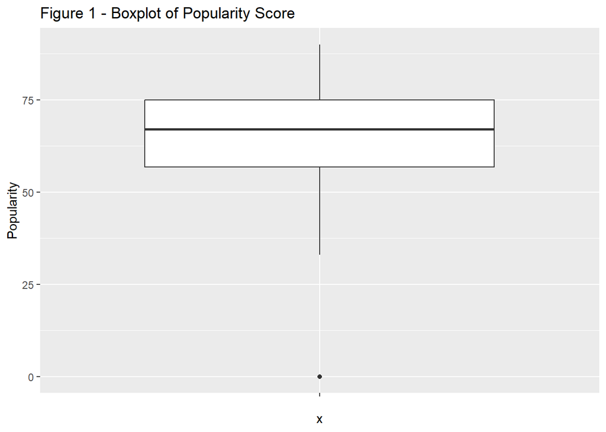

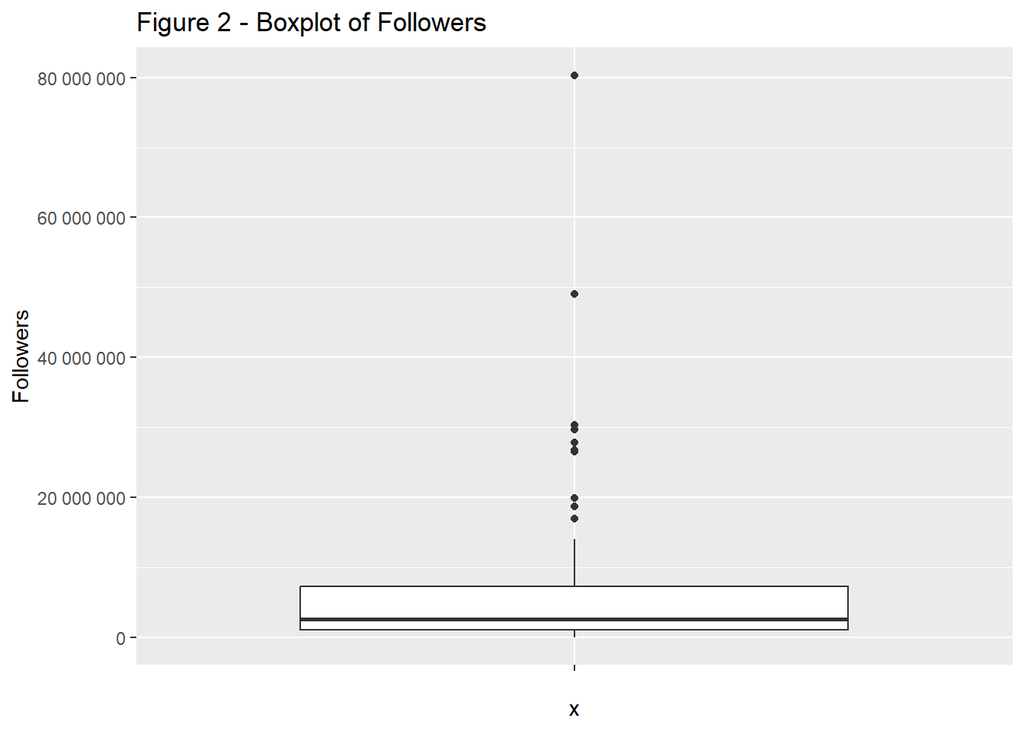

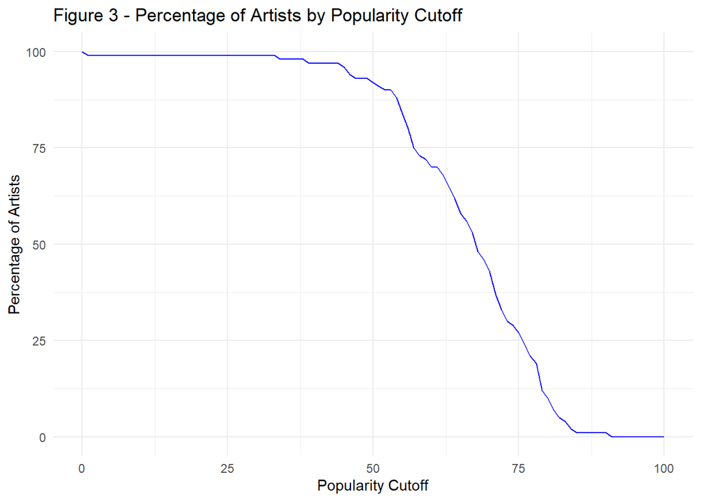

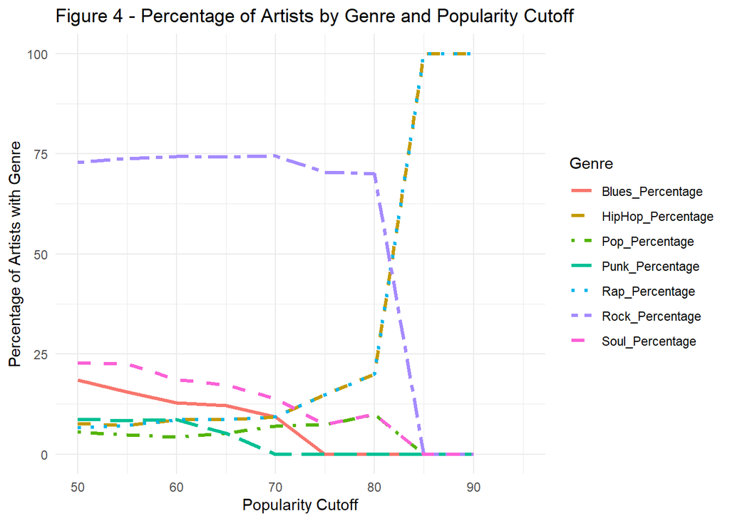

## Appendix: All code in this assignment

```r
# this chunk contains code that sets global options for the entire .Rmd.
# we use include=FALSE to suppress it from the top of the document, but it will still appear in the appendix.

knitr::opts_chunk$set(echo = FALSE, warning = FALSE) # actually set the global chunk options.
# we set echo=FALSE to suppress code such that it by default does not appear throughout the document.
# note: this is different from .Rmd defaultg
library(DBI)
library(RSQLite)
library(RSelenium)
library(rvest)
library(tidyverse)
library(dplyr)
library(rvest)
library(httr)


url <- "https://www.rollingstone.com/music/music-lists/100-greatest-artists-147446/"

response <- GET(url)
html_content <- content(response, "text")

# Parse the HTML content
html <- read_html(html_content)

# Select all <h2> elements
selected_nodes <- html %>% html_nodes("h2")

# Print the text content of selected nodes
selected_text <- selected_nodes %>% html_text()


url2 <- "https://www.rollingstone.com/music/music-lists/100-greatest-artists-147446/the-band-2-88489/"


response2 <- GET(url2)
html_content2 <- content(response2, "text")

# Parse the HTML content
html2 <- read_html(html_content2)

# Select all <h2> elements
selected_nodes2 <- html2 %>% html_nodes("h2")

# Print the text content of selected nodes
selected_text2 <- selected_nodes2 %>% html_text()



concatenated_list <- rev(c(selected_text[1:50], selected_text2[1:50]))

# Print the concatenated list
#print(concatenated_list)


number_column <- 1:100
artist_column <- concatenated_list

# Combine into a data frame
artists_table <- data.frame(Number = number_column, Artist = artist_column)

# Print the table
#print(artists_table)


library(httr)
env_file_path <- "C:\\Users\\daelk\\OneDrive\\Desktop\\lse\\MY472\\spotify.env"

# Read the .env file using the specified path
readRenviron(env_file_path)
client_id <- Sys.getenv("client_id")
client_secret <- Sys.getenv("client_secret")

# Define the URL
token_url <- "https://accounts.spotify.com/api/token"

# Create a body with the grant_type and client credentials
body <- list(
  grant_type = "client_credentials",
  client_id = client_id,
  client_secret = client_secret
)

# Make a POST request to obtain the access token
response <- POST(token_url, body = body, encode = "form")

# Extract the access token from the response
access_token <- content(response)$access_token

library(httr)
library(jsonlite)

# Function to fetch artist information from Spotify API
get_artist_info <- function(artist_name, access_token) {
  # Your Spotify API access token (replace 'YOUR_ACCESS_TOKEN' with your actual token)


  # Base URL for Spotify API endpoints
  base_url <- "https://api.spotify.com/v1/search"

  # API request to search for the artist
  response <- GET(
    url = base_url,
    query = list(q = artist_name, type = "artist"),
    add_headers(Authorization = paste("Bearer", access_token))
  )

  # Extracting relevant information from the API response
  if (http_type(response) == "application/json") {
    artist_info <- content(response, as = "parsed")
    if (length(artist_info$artists$items) > 0) {
      # Extract necessary information (e.g., genre, popularity, followers, etc.)
      artist <- artist_info$artists$items[[1]]
      artist_data <- data.frame(
        Artist = artist$name,
        Genres = toString(artist$genres),
        Popularity = artist$popularity,
        Followers = artist$followers$total
        # Add more fields as needed
      )
      return(artist_data)
    } else {
      return(NULL)  # Artist not found
    }
  } else {
    return(NULL)  # Invalid response
  }
}

# Assuming `artists_table` contains the table with artist names
artist_names <- artists_table$Artist


# Iterate through each artist in the table and fetch their information
artist_info_list <- lapply(artist_names, function(artist) {
  get_artist_info(artist, access_token)
})

# Combine the fetched information into a single data frame
combined_info <- do.call(rbind, Filter(Negate(is.null), artist_info_list))

# Print the combined information
#print(combined_info)

library(dplyr)
library(ggplot2)

# Calculate statistics for popularity score
popularity_stats <- combined_info %>%
  summarize(
    mean_popularity = mean(Popularity),
    median_popularity = median(Popularity),
    q1_popularity = quantile(Popularity, 0.25),
    q3_popularity = quantile(Popularity, 0.75)
  )

# Calculate statistics for followers
followers_stats <- combined_info %>%
  summarize(
    mean_followers = mean(Followers),
    median_followers = median(Followers),
    q1_followers = quantile(Followers, 0.25),
    q3_followers = quantile(Followers, 0.75)
  )

# Create a boxplot for popularity score and followers
popularity_boxplot <- ggplot(combined_info, aes(x = "", y = Popularity)) +
  geom_boxplot() +
  labs(title = "Figure 1 - Boxplot of Popularity Score")

followers_boxplot <- ggplot(combined_info, aes(x = "", y = Followers)) +
  geom_boxplot() +
  labs(title = "Figure 2 - Boxplot of Followers") +
  scale_y_continuous(labels = scales::number_format())


print(popularity_boxplot)
print(followers_boxplot)

library(ggplot2)
library(dplyr)


TS_info_list <- get_artist_info("Taylor Swift", access_token)

# Create an empty data frame to store the results
popularity_summary <- data.frame(
  "Popularity_cutoff" = 0:100,  # Popularity cutoff values from 0 to 100
  "Percent_of_artists" = NA    # Initialize the Percent_of_artists column with NA
)

# Calculate the percentage of artists meeting each Popularity_cutoff
for (i in 1:nrow(popularity_summary)) {
  popularity_cutoff <- popularity_summary[i, "Popularity_cutoff"]
  percent_artists <- nrow(filter(combined_info, Popularity >= popularity_cutoff)) / nrow(combined_info) * 100
  popularity_summary[i, "Percent_of_artists"] <- percent_artists
}

View(popularity_summary)

ggplot(popularity_summary, aes(x = Popularity_cutoff, y = Percent_of_artists)) +
  geom_line(color = "blue") +
  labs(title = "Figure 3 - Percentage of Artists by Popularity Cutoff",
       x = "Popularity Cutoff",
       y = "Percentage of Artists") +
  theme_minimal()
#preparing for genre analysis
```

```r
popularity_thresholds <- c(50, 55, 60, 65, 70, 75, 80, 85, 90, 95)

# Calculate percentages for different popularity thresholds and create data frames
for (threshold in popularity_thresholds) {
  # Filter data based on popularity threshold
  filtered_data <- combined_info %>%
    filter(Popularity >= threshold)

  # Create a data frame for each threshold
  assign(paste0("enduring_artists_", threshold), filtered_data)
}

calculate_genre_percentage <- function(data, genres_column, genre) {
  num_genre_artists <- data %>%
    filter(grepl(genre, tolower(.data[[genres_column]]))) %>%
    nrow()

  percentage_genre_artists <- (num_genre_artists / nrow(data)) * 100

  return(percentage_genre_artists)
}

# Calculate percentages for different datasets and genres
rock_artists_percent_50 <- calculate_genre_percentage(enduring_artists_50, "Genres", "rock")
rock_artists_percent_55 <- calculate_genre_percentage(enduring_artists_55, "Genres", "rock")
rock_artists_percent_60 <- calculate_genre_percentage(enduring_artists_60, "Genres", "rock")
rock_artists_percent_65 <- calculate_genre_percentage(enduring_artists_65, "Genres", "rock")
rock_artists_percent_70 <- calculate_genre_percentage(enduring_artists_70, "Genres", "rock")
rock_artists_percent_75 <- calculate_genre_percentage(enduring_artists_75, "Genres", "rock")
rock_artists_percent_80 <- calculate_genre_percentage(enduring_artists_80, "Genres", "rock")
rock_artists_percent_85 <- calculate_genre_percentage(enduring_artists_85, "Genres", "rock")
rock_artists_percent_90 <- calculate_genre_percentage(enduring_artists_90, "Genres", "rock")
rock_artists_percent_95 <- calculate_genre_percentage(enduring_artists_95, "Genres", "rock")

hiphop_artists_percent_50 <- calculate_genre_percentage(enduring_artists_50, "Genres", "hip hop")
hiphop_artists_percent_55 <- calculate_genre_percentage(enduring_artists_55, "Genres", "hip hop")
hiphop_artists_percent_60 <- calculate_genre_percentage(enduring_artists_60, "Genres", "hip hop")
hiphop_artists_percent_65 <- calculate_genre_percentage(enduring_artists_65, "Genres", "hip hop")
hiphop_artists_percent_70 <- calculate_genre_percentage(enduring_artists_70, "Genres", "hip hop")
hiphop_artists_percent_75 <- calculate_genre_percentage(enduring_artists_75, "Genres", "hip hop")
hiphop_artists_percent_80 <- calculate_genre_percentage(enduring_artists_80, "Genres", "hip hop")
hiphop_artists_percent_85 <- calculate_genre_percentage(enduring_artists_85, "Genres", "hip hop")
hiphop_artists_percent_90 <- calculate_genre_percentage(enduring_artists_90, "Genres", "hip hop")
hiphop_artists_percent_95 <- calculate_genre_percentage(enduring_artists_95, "Genres", "hip hop")

rap_artists_percent_50 <- calculate_genre_percentage(enduring_artists_50, "Genres", "rap")
rap_artists_percent_55 <- calculate_genre_percentage(enduring_artists_55, "Genres", "rap")
rap_artists_percent_60 <- calculate_genre_percentage(enduring_artists_60, "Genres", "rap")
rap_artists_percent_65 <- calculate_genre_percentage(enduring_artists_65, "Genres", "rap")
rap_artists_percent_70 <- calculate_genre_percentage(enduring_artists_70, "Genres", "rap")
rap_artists_percent_75 <- calculate_genre_percentage(enduring_artists_75, "Genres", "rap")
rap_artists_percent_80 <- calculate_genre_percentage(enduring_artists_80, "Genres", "rap")
rap_artists_percent_85 <- calculate_genre_percentage(enduring_artists_85, "Genres", "rap")
rap_artists_percent_90 <- calculate_genre_percentage(enduring_artists_90, "Genres", "rap")
rap_artists_percent_95 <- calculate_genre_percentage(enduring_artists_95, "Genres", "rap")

blues_artists_percent_50 <- calculate_genre_percentage(enduring_artists_50, "Genres", "blues")
blues_artists_percent_55 <- calculate_genre_percentage(enduring_artists_55, "Genres", "blues")
blues_artists_percent_60 <- calculate_genre_percentage(enduring_artists_60, "Genres", "blues")
blues_artists_percent_65 <- calculate_genre_percentage(enduring_artists_65, "Genres", "blues")
blues_artists_percent_70 <- calculate_genre_percentage(enduring_artists_70, "Genres", "blues")
blues_artists_percent_75 <- calculate_genre_percentage(enduring_artists_75, "Genres", "blues")
blues_artists_percent_80 <- calculate_genre_percentage(enduring_artists_80, "Genres", "blues")
blues_artists_percent_85 <- calculate_genre_percentage(enduring_artists_85, "Genres", "blues")
blues_artists_percent_90 <- calculate_genre_percentage(enduring_artists_90, "Genres", "blues")
blues_artists_percent_95 <- calculate_genre_percentage(enduring_artists_95, "Genres", "blues")

pop_artists_percent_50 <- calculate_genre_percentage(enduring_artists_50, "Genres", "pop")
pop_artists_percent_55 <- calculate_genre_percentage(enduring_artists_55, "Genres", "pop")
pop_artists_percent_60 <- calculate_genre_percentage(enduring_artists_60, "Genres", "pop")
pop_artists_percent_65 <- calculate_genre_percentage(enduring_artists_65, "Genres", "pop")
pop_artists_percent_70 <- calculate_genre_percentage(enduring_artists_70, "Genres", "pop")
pop_artists_percent_75 <- calculate_genre_percentage(enduring_artists_75, "Genres", "pop")
pop_artists_percent_80 <- calculate_genre_percentage(enduring_artists_80, "Genres", "pop")
pop_artists_percent_85 <- calculate_genre_percentage(enduring_artists_85, "Genres", "pop")
pop_artists_percent_90 <- calculate_genre_percentage(enduring_artists_90, "Genres", "pop")
pop_artists_percent_95 <- calculate_genre_percentage(enduring_artists_95, "Genres", "pop")

soul_artists_percent_50 <- calculate_genre_percentage(enduring_artists_50, "Genres", "soul")
soul_artists_percent_55 <- calculate_genre_percentage(enduring_artists_55, "Genres", "soul")
soul_artists_percent_60 <- calculate_genre_percentage(enduring_artists_60, "Genres", "soul")
soul_artists_percent_65 <- calculate_genre_percentage(enduring_artists_65, "Genres", "soul")
soul_artists_percent_70 <- calculate_genre_percentage(enduring_artists_70, "Genres", "soul")
soul_artists_percent_75 <- calculate_genre_percentage(enduring_artists_75, "Genres", "soul")
soul_artists_percent_80 <- calculate_genre_percentage(enduring_artists_80, "Genres", "soul")
soul_artists_percent_85 <- calculate_genre_percentage(enduring_artists_85, "Genres", "soul")
soul_artists_percent_90 <- calculate_genre_percentage(enduring_artists_90, "Genres", "soul")
soul_artists_percent_95 <- calculate_genre_percentage(enduring_artists_95, "Genres", "soul")
```

```r
punk_artists_percent_50 <- calculate_genre_percentage(enduring_artists_50, "Genres", "punk")
punk_artists_percent_55 <- calculate_genre_percentage(enduring_artists_55, "Genres", "punk")
punk_artists_percent_60 <- calculate_genre_percentage(enduring_artists_60, "Genres", "punk")
punk_artists_percent_65 <- calculate_genre_percentage(enduring_artists_65, "Genres", "punk")
punk_artists_percent_70 <- calculate_genre_percentage(enduring_artists_70, "Genres", "punk")
punk_artists_percent_75 <- calculate_genre_percentage(enduring_artists_75, "Genres", "punk")
punk_artists_percent_80 <- calculate_genre_percentage(enduring_artists_80, "Genres", "punk")
punk_artists_percent_85 <- calculate_genre_percentage(enduring_artists_85, "Genres", "punk")
punk_artists_percent_90 <- calculate_genre_percentage(enduring_artists_90, "Genres", "punk")
punk_artists_percent_95 <- calculate_genre_percentage(enduring_artists_95, "Genres", "punk")
#accumulating the genre data into data frames
rock_percentages <- data.frame(
  "Dataset" = c(50, 55, 60, 65, 70, 75, 80, 85, 90, 95),
  "Rock_Percentage" = c(rock_artists_percent_50, rock_artists_percent_55, rock_artists_percent_60, rock_artists_percent_65, rock_artists_percent_70, rock_artists_percent_75, rock_artists_percent_80, rock_artists_percent_85, rock_artists_percent_90, rock_artists_percent_95)
)

hiphop_percentages <- data.frame(
  "Dataset" = c(50, 55, 60, 65, 70, 75, 80, 85, 90, 95),
  "HipHop_Percentage" = c( hiphop_artists_percent_50, hiphop_artists_percent_55, hiphop_artists_percent_60, hiphop_artists_percent_65, hiphop_artists_percent_70, hiphop_artists_percent_75, hiphop_artists_percent_80, hiphop_artists_percent_85, hiphop_artists_percent_90, hiphop_artists_percent_95)
)

rap_percentages <- data.frame(
  "Dataset" = c(50, 55, 60, 65, 70, 75, 80, 85, 90, 95),
  "Rap_Percentage" = c(rap_artists_percent_50, rap_artists_percent_55, rap_artists_percent_60, rap_artists_percent_65, rap_artists_percent_70, rap_artists_percent_75, rap_artists_percent_80, rap_artists_percent_85, rap_artists_percent_90, rap_artists_percent_95)
)

blues_percentages <- data.frame(
"Dataset" = c(50, 55, 60, 65, 70, 75, 80, 85, 90, 95),
  "Blues_Percentage" = c( blues_artists_percent_50, blues_artists_percent_55, blues_artists_percent_60, blues_artists_percent_65, blues_artists_percent_70, blues_artists_percent_75, blues_artists_percent_80, blues_artists_percent_85, blues_artists_percent_90, blues_artists_percent_95)
)

pop_percentages <- data.frame(
 "Dataset" = c(50, 55, 60, 65, 70, 75, 80, 85, 90, 95),
  "Pop_Percentage" = c( pop_artists_percent_50, pop_artists_percent_55, pop_artists_percent_60, pop_artists_percent_65, pop_artists_percent_70, pop_artists_percent_75, pop_artists_percent_80, pop_artists_percent_85, pop_artists_percent_90, pop_artists_percent_95)
)

soul_percentages <- data.frame(
  "Dataset" = c(50, 55, 60, 65, 70, 75, 80, 85, 90, 95),
  "Soul_Percentage" = c( soul_artists_percent_50, soul_artists_percent_55, soul_artists_percent_60, soul_artists_percent_65, soul_artists_percent_70, soul_artists_percent_75, soul_artists_percent_80, soul_artists_percent_85, soul_artists_percent_90, soul_artists_percent_95)
)

punk_percentages <- data.frame(
  "Dataset" = c(50, 55, 60, 65, 70, 75, 80, 85, 90, 95),
  "Punk_Percentage" = c(punk_artists_percent_50, punk_artists_percent_55, punk_artists_percent_60, punk_artists_percent_65, punk_artists_percent_70, punk_artists_percent_75, punk_artists_percent_80, punk_artists_percent_85, punk_artists_percent_90, punk_artists_percent_95)
)


#combining into one dataframe


# Pivoting each genre dataframe
rock_long <- pivot_longer(rock_percentages, cols = -Dataset, names_to = "Genre", values_to = "Percentage")
hiphop_long <- pivot_longer(hiphop_percentages, cols = -Dataset, names_to = "Genre", values_to = "Percentage")
rap_long <- pivot_longer(rap_percentages, cols = -Dataset, names_to = "Genre", values_to = "Percentage")
blues_long <- pivot_longer(blues_percentages, cols = -Dataset, names_to = "Genre", values_to = "Percentage")
pop_long <- pivot_longer(pop_percentages, cols = -Dataset, names_to = "Genre", values_to = "Percentage")
soul_long <- pivot_longer(soul_percentages, cols = -Dataset, names_to = "Genre", values_to = "Percentage")
punk_long <- pivot_longer(punk_percentages, cols = -Dataset, names_to = "Genre", values_to = "Percentage")

# Combine all pivoted dataframes
combined_genres_long <- bind_rows(rock_long, hiphop_long, rap_long, blues_long, pop_long, soul_long, punk_long)
# Plotting
ggplot(combined_genres_long, aes(x = Dataset, y = Percentage, color = Genre, linetype = Genre)) +
  geom_line(size = 1.2) +
  labs(title = "Figure 4 - Percentage of Artists by Genre and Popularity Cutoff",
       x = "Popularity Cutoff",
       y = "Percentage of Artists with Genre") +
    scale_linetype_manual(values = c("solid", "dashed", "dotdash", "longdash", "dotted","twodash", "dashed", "solid", "dotted", "dotdash"))  +
  theme_minimal()
# this chunk generates the complete code appendix.
# eval=FALSE tells R not to run (``evaluate'') the code here (it was already run before).
```